# Making networks with Twitter data

Dr Elliot Meador

15/01/2019

# Overview

- Pull data from Twitter API
- Prepare data for network
- Plot data in a meaningful way

# Pulling data from Twitter API

```r
library(rtweet)

access_token <- ''
access_secret <- ''
consumer_key <- ''
consumer_secret <- ''

create_token(
  app = '',
  consumer_key = consumer_key,
  consumer_secret = consumer_secret,
  access_token = access_token,
  access_secret = access_secret
)
```

Rtweet has the `get_timeline` function that retrieves a user’s tweets. It has two primary arguments: the user name and the number of tweets to return.

*Caution* Twitter has rate limits. If you ask for too much data too quickly it will time you out, meaning you will have to wait (usually about an hour). You can also be *blacklisted* for spamming or hammering the server. Please see the [Twitter API](https://developer.twitter.com/en/developer-terms/agreement-and-policy.html) for more information.

```r
alfa <- get_timeline('', n = 25) # user handle in the quotes
```

There is quite a lot of really useful information returned in `tibble` format.

```
##  [1] "user_id"                 "status_id"
##  [3] "created_at"              "screen_name"
##  [5] "text"                    "source"
##  [7] "display_text_width"      "reply_to_status_id"
##  [9] "reply_to_user_id"        "reply_to_screen_name"
## [11] "is_quote"                "is_retweet"
## [13] "favorite_count"          "retweet_count"
## [15] "hashtags"                "symbols"
## [17] "urls_url"                "urls_t.co"
## [19] "urls_expanded_url"       "media_url"
## [21] "media_t.co"              "media_expanded_url"
## [23] "media_type"              "ext_media_url"
## [25] "ext_media_t.co"          "ext_media_expanded_url"
## [27] "ext_media_type"          "mentions_user_id"
## [29] "mentions_screen_name"    "lang"
```

[output cut: 29 more lines]

#Grabbing network data using `Tidytext`

- REGEX objects for use in `tidytext`
- Pulled directly from [Text Mining with R](https://www.tidytextmining.com/) by Julia Silge and David Robinson
- These make it easy to pull out the `@` symbol names and removes hyperlinks, etc.

```r
regex <- "@([A-Za-z]+[A-Za-z0-9_]+)(?![A-Za-z0-9_]*\\.)"

replace_reg1 <- 'https://t.co/[A-Za-z\\d]+|'

replace_reg2 <- 'http://[A-Za-z\\d]+|&amp;|&lt;|&gt|RT|https'

replace_reg <- paste0(replace_reg1, replace_reg2)

unnest_reg <-  "([^A-Za-z\\d#@']|'(?![A-Za-z_\\d#@]))"
```

I’ve created a function - by chaining together `dplyr` code - that pulls the data I’m interested in. Mostly, I am interested in users who tweet at other users as if they are having a conversation, specifically if it is reciprocated or not.

```r
pull_mentions <- function(x = tibble) {
  x %>%
    filter(!str_detect(text, '^RT')) %>%
    mutate(text = str_replace_all(text, replace_reg, ''),
           row.id = row_number()) %>%
    unnest_tokens(word,
                  text,
                  token = 'regex',
                  pattern = unnest_reg,
                  collapse = F) %>%
    mutate(mentioned = ifelse(str_detect(word, '@'), word, NA)) %>%
    distinct(mentioned) %>%
    na.omit() %>%
    pull(mentioned)
}



mentions <- pull_mentions(alfa)
```

- The `pull_mentions` function allows us to make a 1-degree network the users I, @elliot_meador, have tweeted at over the last 25 tweets.

We can then loop through each of my 1-degree mentiones (people I tweet at) and pull their timelines using `map_df` from `purrr` and the code above.

```r
foxtrot <- map_df(mentions, function(x) { #map_df merges the dataframes
  get_timeline(x, n = 25)

})
```

The dataframes returned from `rtweet` contain list columns of things like `geo-coordinates` and `hashtags`. This is useful information that we want to keep. So, it’s best to simplify it and then change it into a character vector before `tokenising`.

```r
golf <- echo %>%
  mutate_if(is.list, simplify_all) %>%   # take all lists and simplify
  as_tibble()  %>%
  mutate_if(is.list, as.character) %>%   # change all lists to a character
  filter(!str_detect(text  , '^RT')) %>% # this is the same as above
  mutate(text = str_replace_all(text  , replace_reg, ''),
         row.id = row_number()) %>%
  unnest_tokens(word,
                text,
                token = 'regex',
                pattern = unnest_reg,
                collapse = F) %>%
  mutate(mentioned = ifelse(str_detect(word, '@'), word, NA))
```

The dataframe `golf` contains our network identifiers as well as the tweet text data in a `tidy` format. We can now do our network analysis and sentiment analysis in using this dataframe. We use `graph_from_data_frame` from `igraph`. The `simplify` function removes self-loops.

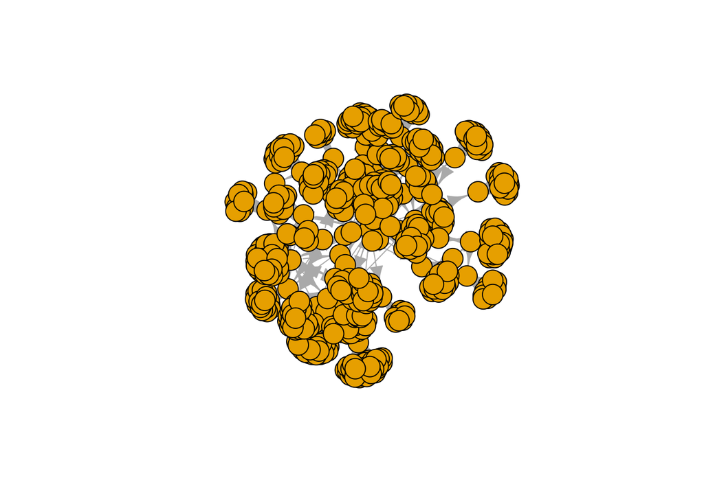

```r
library(RColorBrewer)
Spectral_n <- colorRampPalette(brewer.pal(11, 'Spectral'))

tweet_g <- golf %>%
  transmute(screen_name = str_to_lower(str_c('@', screen_name)),
            mentioned) %>%
  na.omit() %>%
  graph_from_data_frame() %>% # from igraph
  simplify()



plot(tweet_g, vertex.label = NA)
```

# Plotting the network in a meaningful way

`Igraph` can plot the network using the `plot` function, but the base plot can be difficult to read and make sense of, especially if the network is big and complicated.

We need to add some graph ‘attributes’ to decorate the plot and pull something more meaningful from it.

The following block of code uses `dplyr` joins to combine data back and forth until we get a series of color vectors that correspond to the nodes and the edges.

The idea is make the color radiate out from the centre node - which will usually be the first twitter user pulled - out through the network. This way, the reader’s eye can more easily discern the direction of tweets within the network.

```r
library(scales)

tweet_edges <- tweet_g %>%
  as_data_frame() %>%
  as_tibble() %>%
  mutate_all(funs(str_trim(.)))




edge_col <- tweet_edges %>%
  mutate(betweenness = edge.betweenness(tweet_g)) %>%
  arrange(betweenness) %>%
  distinct(from) %>%
  mutate(color = sample(Spectral_n(nrow(.)))) %>%
  right_join(tweet_edges) %>%
  select(name = from, to, color)



tweet_nodes <- tweet_g %>%
  as_data_frame(., 'vertices') %>%
  as_tibble() %>%
  mutate_all(funs(str_trim(.)))



node_col_temp <- tweet_nodes %>%
  mutate(in.degree = degree(tweet_g, mode = 'in')) %>%
  left_join(edge_col) %>%
  select(-to) %>%
  distinct() %>%
  filter(is.na(color)) %>%
  distinct() %>%
  filter(in.degree == 1) %>%
  pull(name)


node_add <- edge_col %>%
  filter(to %in% node_col_temp) %>%
  select(name = to, color.2 = color)



n_shared_node <- tweet_nodes %>%
  left_join(edge_col) %>%
  select(-to) %>%
  distinct() %>%
  left_join(node_add) %>%
  mutate_all(funs(ifelse(is.na(.), '', .))) %>%
  unite(color, color, color.2, sep = '') %>%
  filter(color == '') %>%
  nrow()

node_col <- tweet_nodes %>%
  left_join(edge_col) %>%
  select(-to) %>%
  distinct() %>%
  left_join(node_add) %>%
  mutate_all(funs(ifelse(is.na(.), '', .))) %>%
  unite(color, color, color.2, sep = '') %>%
  mutate(color = ifelse(color == '', Spectral_n(n_shared_node), color))

edge.cols.ad <- map2(edge_col$color,
                     rescale(edge.betweenness(tweet_g), 0.5, 1),
                     function(x, y) {
                       adjustcolor(x, y)
                     }) %>%
                     flatten_chr()



node.cols.ad <- map2(node_col$color,
                     rescale(degree(tweet_g), 0.5, 1),
                     function(x, y){
                        adjustcolor(x, y)
                     }) %>%
                     flatten_chr()
```

Let’s put this into the plot using the base R function.

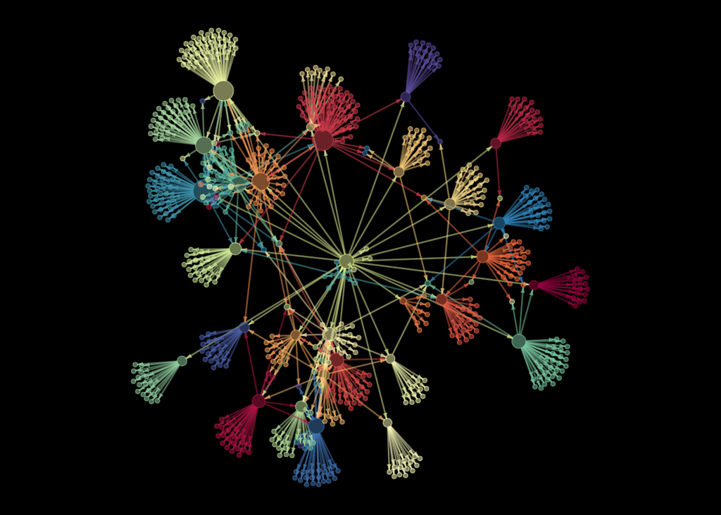

```r
par(mar = c(0,0,0,0), bg = 'black')
plot(
  tweet_g,
  vertex.label = NA,
  vertex.color =node.cols.ad,
  vertex.frame.color = node.cols.ad,
  vertex.size = rescale(degree(tweet_g),c(2,10)),
  edge.color = edge.cols.ad,
  edge.arrow.size = .25,
  edge.width = 1.5,
  asp = 1)
```